# Individual1

Armando Castillo

I decided to do the lab by myself

Importing data and reorganizing it

```r
dat <- readxl::read_xls('C:/Users/Arman/ds202_lab3/GSS.xls')
View(dat)
library(ggplot2)
library(tidyverse)
dat$`Highest year of school completed` <- as.numeric(dat$`Highest year of school completed`)
dat <- na.omit(dat)
head(dat)
```

```
## # A tibble: 6 x 6
##   `Labor force st~ `Marital status` `Highest year o~ `Respondents se~
##   <chr>            <chr>                       <dbl> <chr>
## 1 Working fulltime Never married                  16 Female
## 2 Retired          Married                        10 Male
## 3 Working parttime Married                        12 Female
## 4 Working fulltime Married                        17 Female
## 5 Keeping house    Married                        12 Female
## 6 Working fulltime Never married                  14 Male
## # ... with 2 more variables: `Political party affiliation` <chr>, `General
## #   happiness` <chr>
```

1. Find the average years of education for the respondents with each political party affiliation. Arrange your output in a meaningful order and print. Describe any patterns you find.

```r
edu_pol <- dat %>% group_by(`Political party affiliation`) %>% dplyr::summarise(Mean=mean(`Highest year of school completed`, na.rm=TRUE)) %>% arrange(Mean)
edu_pol
```

```
## # A tibble: 10 x 2
##    `Political party affiliation`  Mean
##    <chr>                         <dbl>
##  1 Don't know                     10.9
##  2 No answer                      12.3
##  3 Independent                    12.3
##  4 Strong democrat                12.5
##  5 Not str democrat               12.6
##  6 Ind,near dem                   13.2
##  7 Not str republican             13.3
##  8 Ind,near rep                   13.3
##  9 Other party                    13.4
## 10 Strong republican              13.4
```

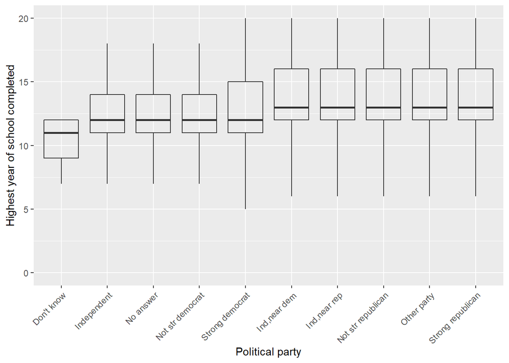

```r
ggplot(dat, aes(x=reorder(`Political party affiliation`, `Highest year of school completed`, FUN = median), y=`Highest year of school completed`)) + geom_boxplot(alpha = 0) + theme(axis.text.x = element_text(angle = 45, hjust = 1)) + xlab('Political party')
```

Answer: Looks like strong republicans are the most educated , with no answer and don’t know being the least educated. Also Other party seems to fair very well being 2nd most educated with str democrats being in the middle.

2. Create a single data frame containing records for the better educated respondents in each political party affiliation. A “better educated” respondent is someone who has strictly more years of education than the median in the same party affiliation. Print the structure of the data frame

```r
best_edu <- data.frame()
best_edu <- dat %>% group_by(`Political party affiliation`) %>% filter(`Highest year of school completed` > median(`Highest year of school completed`, na.rm=TRUE))

more_edu <- nrow(best_edu) / nrow(dat)
more_edu
```

```
## [1] 0.4307131
```

Answer: It says that about 43.07131% have a greater education that theier affiliated political party

3. How is the happiness of a respondent related to his/her marriage status? Define that a person is happy if the response to question is “Very happy” or “Pretty happy”.

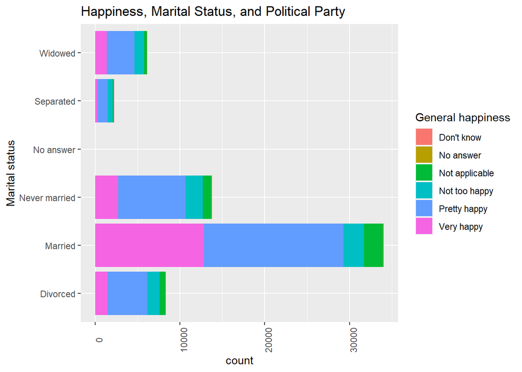

```r
ggplot(dat, aes(x=`Marital status`, fill=`General happiness`)) + geom_bar() + coord_flip() + ggtitle("Happiness, Marital Status, and Political Party") + theme(axis.text.x = element_text(angle = 90))
```

```r
dat%>%
  select(`General happiness`, `Political party affiliation`, `Marital status`)%>%
  group_by(`Political party affiliation`, `Marital status`)%>%
  count(`General happiness`)
```

```
## # A tibble: 269 x 4
## # Groups:   Political party affiliation, Marital status [58]
##    `Political party affiliation` `Marital status` `General happiness`     n
##    <chr>                         <chr>            <chr>               <int>
##  1 Don't know                    Married          Pretty happy            2
##  2 Don't know                    Married          Very happy              4
##  3 Don't know                    Never married    Not too happy           1
##  4 Don't know                    Never married    Very happy              1
##  5 Don't know                    Separated        Not too happy           1
##  6 Don't know                    Widowed          Not too happy           1
##  7 Don't know                    Widowed          Pretty happy            1
##  8 Ind,near dem                  Divorced         No answer               3
##  9 Ind,near dem                  Divorced         Not applicable         74
## 10 Ind,near dem                  Divorced         Not too happy         200
## # ... with 259 more rows
```

Answer: Most people whom are Very happy and pretty happy are ones whom are married. The next group would be the never married group they have a lot of pretty happy people.

4. Does party affiliation affect the relationship you found in the last question?

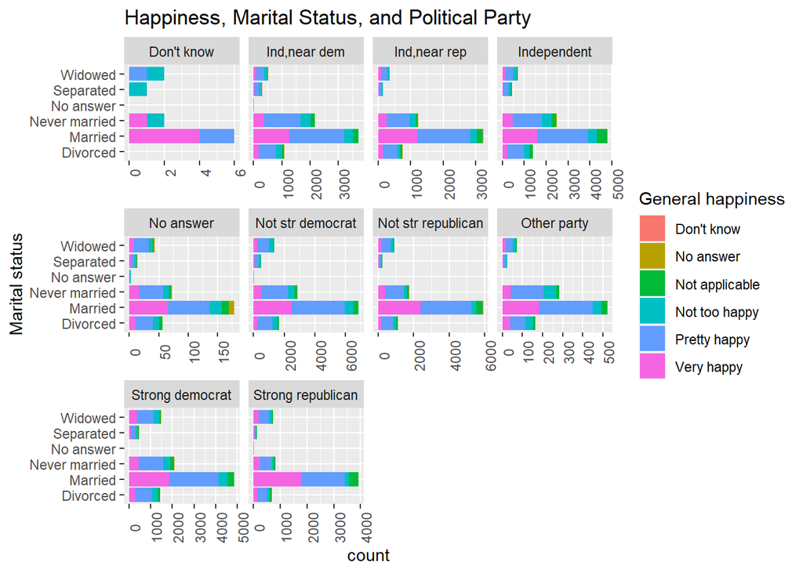

```r
ggplot(dat, aes(x=`Marital status`, fill=`General happiness`)) + geom_bar() + facet_wrap(~`Political party affiliation`, scales="free_x")+coord_flip() + ggtitle("Happiness, Marital Status, and Political Party") + theme(axis.text.x = element_text(angle = 90))
```

```r
dat%>%
  select(`General happiness`, `Political party affiliation`, `Marital status`)%>%
  group_by(`Political party affiliation`, `Marital status`)%>%
  count(`General happiness`)
```

```
## # A tibble: 269 x 4
## # Groups:   Political party affiliation, Marital status [58]
##    `Political party affiliation` `Marital status` `General happiness`     n
##    <chr>                         <chr>            <chr>               <int>
##  1 Don't know                    Married          Pretty happy            2
##  2 Don't know                    Married          Very happy              4
##  3 Don't know                    Never married    Not too happy           1
##  4 Don't know                    Never married    Very happy              1
##  5 Don't know                    Separated        Not too happy           1
##  6 Don't know                    Widowed          Not too happy           1
##  7 Don't know                    Widowed          Pretty happy            1
##  8 Ind,near dem                  Divorced         No answer               3
##  9 Ind,near dem                  Divorced         Not applicable         74
## 10 Ind,near dem                  Divorced         Not too happy         200
## # ... with 259 more rows
```

Answer: Political party does not seem to affect level happiness very much as there is a decently equal distribution among all political parties.

5. How is marital status related to the education of a respondent? What are possible reasons accounting for the patterns you see?

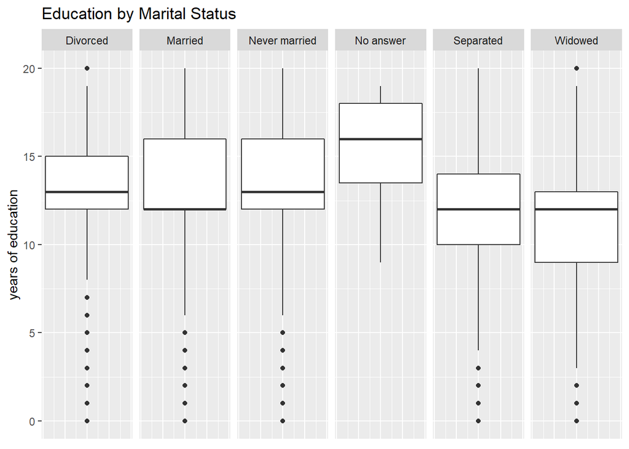

```r
dat %>% group_by(`Marital status`) %>% ggplot(aes(x=`Highest year of school completed`)) + geom_boxplot() + facet_grid(~`Marital status`,)+ coord_flip()+
  xlab('years of education') + theme(axis.text.x = element_blank(),axis.ticks.x  = element_blank()) +
  ggtitle('Education by Marital Status')
```

Answer: People who responded with no answer have the highest median yeas of education. Widows have the on average the lowest years of education.